# T Goldberg Draft Code

2026-04-10

## Library and Data Loading

```r
library(OncoDataSets)
library(dplyr)
```

```r
library(ggplot2)
library(corrplot)
library(lattice)
library(caret)
library(kerndwd)
library(randomForest)
df <- OncoDataSets::BreastCancerWI_df
```

## Dimensional Reduction

References Used: (https://rstudio-pubs-static.s3.amazonaws.com/455435_30729e265f7a4d049400d03a18e218db.html)

The goal is to identify which variables contain the most information and use these to train the models.

```r
entropy <- function(X) {
  #create frequency table of X (count table devided by length of X)
  freq <- table(X)/length(X)

  #make frequencies a vector
  vec <- as.data.frame(freq)[,2]

  #remove any zero counts if they occur because we will take log
  vec<-vec[vec>0]

  #entropy equation
  -sum(vec * log2(vec))
}
```

```r
#looking at table
freq <- table(df$diagnosis)/length(df$diagnosis)
freq

#looking at vector
vec <- as.data.frame(freq)[,2]
vec

#testing function
entf<- entropy(df$diagnosis)
entf

#manually doing math
entm <- -(vec[1]*log2(vec[1]) + vec[2]*log2(vec[2]))
entm

#check
entf == entm
```

[output not shown]

Now to define information gain.

Our predictive variables are numerical but entropy works with categorical variables, so we will need to define a number of ranges to cover each and make them discrete categories, since entropy takes discrete values. We can define these by dividing the whole range into a number of bins.

Information gain will need to be calculated for each potential feature in our dataset that might provide information on what we want to predict (diagnosis), which is the ‘parent’.

Information Gain (Numeric)

```r
#I'm going to split the function the resource used into two to more easily test and view it. The first part returns dd_data

dd <-function(data, feature, parent, bins) {
 #clean out N/As
  data <- data[!is.na(data[,feature]),]

  #now break up our dataset into bins based on length
  data$cat<-cut(data[,feature], breaks=bins, labels=c(1:bins))

  #now we need to calculate the entropy of each feature (e)
  #we will need to know how many items fall in each bin (n)
  #to calculate frequency
  #we can also look at max and mins for each bin if we want

  dd_data <- data %>% group_by(cat) %>% summarise(e=entropy(get(parent)), n = length(get(parent)), min=min(get(feature)), max=max(get(feature))
  )

  #now we need the probability for each feature value
  dd_data$p<-dd_data$n/nrow(data)

  return(dd_data)
}

#now the IG
ig_num <- function(data, feature, parent, bins=5) {

  #entropy for our parent
  eP <- entropy(data[,parent])

  #call dd
  dd_data <- dd(data, feature, parent, bins)

  #and finally we can get our information gain
  IG <- eP - sum(dd_data$p*dd_data$e)

  return(IG)
}
```

```r
#test on one feature first
ig_num(df, "radius_mean", "diagnosis")

#look at dd_data
dd(df,"radius_mean", "diagnosis", 5)
```

[output not shown]

It looks like 5 bins may be too much for this category, as the feature entropy drops to zero for the last two bins.

Trying different bin numbers:

```r
ig_num(df, "radius_mean", "diagnosis", bins=3)

#look at dd_data
dd(df,"radius_mean", "diagnosis", 3)
```

[output not shown]

Interestingly, we still lose the last bin, and the information gain drops, so 5 bins is better!

More bin number tests:

```r
ig_num(df, "radius_mean", "diagnosis", bins=4)
ig_num(df, "radius_mean", "diagnosis", bins=7)
ig_num(df, "radius_mean", "diagnosis", bins=10)
ig_num(df, "radius_mean", "diagnosis", bins=15)
```

[output not shown]

As expected, as number of bins increases, the IG increases, but at a certain point there are fewer gains.

We may want to consider whether different variables should have different bin numbers.

Lets look at information gain for 5 bins with all variables.

```r
#for loop

#define empty vectors
col_name<-character()
ig<-numeric()

features <- names(df)
length(features)
```

```
## [1] 31
```

```r
for (i in 2:length(features)){
  col_name[i]<-features[i]
  ig[i]<-ig_num(df, names(df)[i], "diagnosis", bins=5)
}

ig_df<-arrange(data.frame(cbind(col_name, round(ig,2))),desc(V2))

ig_df
```

| col_name | V2 |
| --- | --- |
| concave_points_peak | 0.59 |
| concave_points_mean | 0.57 |
| perimeter_peak | 0.54 |
| radius_peak | 0.53 |
| perimeter_mean | 0.49 |
| area_peak | 0.47 |
| radius_mean | 0.46 |
| concavity_mean | 0.46 |
| area_mean | 0.44 |
| concavity_peak | 0.41 |

[output cut: 21 more lines]

We definitely need to weed out variables that are highly cross correlated.

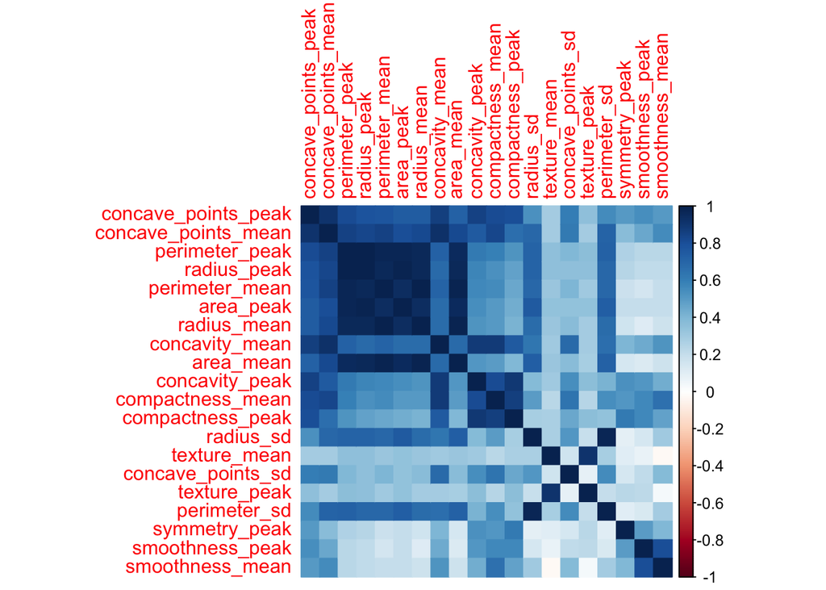

```r
M = cor(select(df,concave_points_peak, c(ig_df$col_name[1:20])))
corrplot(M, method = 'color') # colorful number
```

Decided to Use PCA to limit variables.

PCAs (By Carolyn)

```r
pca <- prcomp(BreastCancerWI_df[, -1], center=TRUE, scale.=TRUE) #removing diagnostics column
data.pca <- data.frame(diagnosis = df$diagnosis, pca$x[,1:10])
```

Tried Entropy on PCAs just to See

```r
col_name2<-character()
ig2<-numeric()

features2 <- names(data.pca)
length(features2)

for (i in 2:length(features2)){
  col_name2[i]<-features2[i]
  ig2[i]<-ig_num(data.pca, names(data.pca)[i], "diagnosis", bins=5)
}

ig_df2<-arrange(data.frame(cbind(col_name2, round(ig2,2))),desc(V2))

ig_df2
```

[output not shown]

## Initial Model Training

Source: https://machinelearningmastery.com/machine-learning-in-r-step-by-step/ Needed package ‘caret’

Set up training and verification datasets (70:30)

```r
#will need multiple seeds, easiest to set up vector of seeds from one seed
set.seed(456)

#grabs indices of 70% of data with preserved class distribution for diagnosis
train.index <- createDataPartition(data.pca$diagnosis, p=0.70, list=FALSE)

#creates training dataset
training <- data.pca[train.index,]

#creates validation dataset
validation <- data.pca[-train.index,]
```

Training Harness (Setting up our training parameters)

```r
#We will need multiple seeds throughout process, can set up seed vector of length one per model
#we need one seed per model
#should be (model types x number of splits x number of repeats for repeated cross validation)
#paper does not do this!!!
#also makes it seem like they are doing 70/30 for training as well when its 9/10

set.seed(456)

seedlist <- vector(mode = "list", length = 31)
for (i in 1:30) seedlist[[i]] <- sample.int(1000, 22)
seedlist[[31]] <- sample.int(1000, 1)

#as paper has done, we use repeated cross-validation with k=3 and 10 part splits

control <- trainControl(method = "repeatedcv", number=10, repeats = 3, seeds = seedlist)
metric <- "Accuracy"
```

```r
fit.lda2 <- train(diagnosis~., data=training, method="lda2", metric=metric, trControl=control)
fit.rf <- train(diagnosis~., data=training, method="rf", metric=metric, trControl=control)
```

```r
results <- resamples(list(lda=fit.lda2, rf=fit.rf))
summary(results)
```

```
##
## Call:
## summary.resamples(object = results)
##
## Models: lda, rf
## Number of resamples: 30
##
## Accuracy
##          Min. 1st Qu. Median      Mean  3rd Qu. Max. NA's
## lda 0.8717949   0.925  0.925 0.9397436 0.968750    1    0
## rf  0.8500000   0.925  0.950 0.9457692 0.974359    1    0
##
## Kappa
##          Min.   1st Qu.    Median      Mean   3rd Qu. Max. NA's
## lda 0.6976744 0.8333333 0.8378378 0.8659285 0.9327928    1    0
## rf  0.6521739 0.8389047 0.8933333 0.8833157 0.9447098    1    0
```

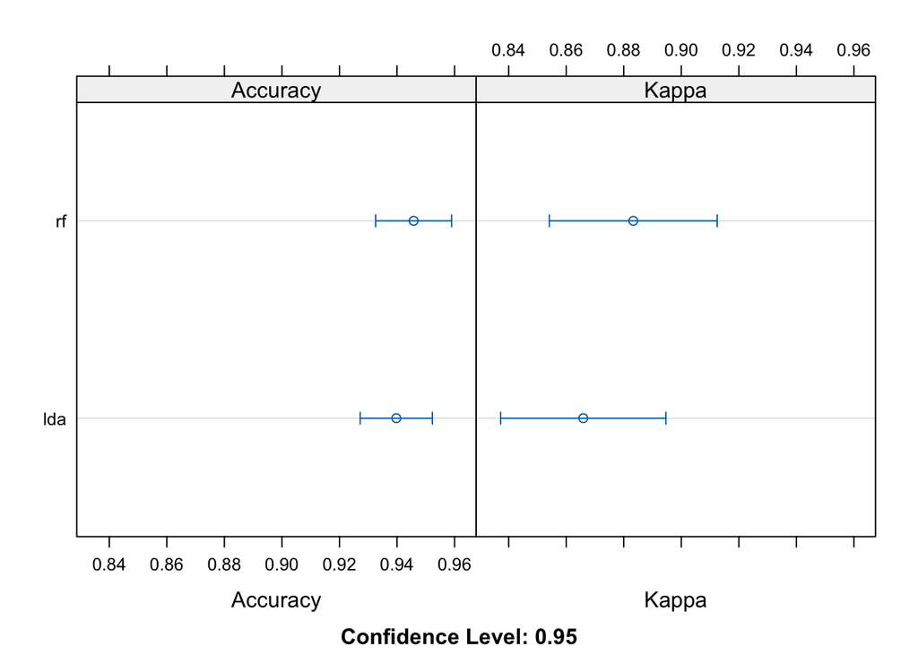

```r
dotplot(results)
```

```r
print(fit.rf)
```

```
## Random Forest
##
## 399 samples
##  10 predictor
##   2 classes: '0', '1'
##
## No pre-processing
## Resampling: Cross-Validated (10 fold, repeated 3 times)
## Summary of sample sizes: 359, 359, 359, 359, 359, 359, ...
## Resampling results across tuning parameters:
##
##   mtry  Accuracy   Kappa
##    2    0.9407265  0.8732915
##    6    0.9457692  0.8833157
##   10    0.9290385  0.8473691
##
## Accuracy was used to select the optimal model using the largest value.
## The final value used for the model was mtry = 6.
```

## Scrap Heap (ignore)

```r
#install.packages("OncoDataSets")
#needs bioconductor installs for maftools and tcgabiolinks
#library(OncoDataSets)
#library(maftools)
#library(TCGAbiolinks)
```

```r
#query <- GDCquery(
    #project = "TCGA-CHOL",
    #data.category = "Simple Nucleotide Variation",
    #access = "open",
    #data.type = "Masked Somatic Mutation",
    #workflow.type = "Aliquot Ensemble Somatic Variant Merging and Masking"
#)
#GDCdownload(query)
#maf <- GDCprepare(query)

#https://bioconductor.org/packages//release/bioc/vignettes/TCGAbiolinks/inst/doc/mutation.html
```

```r
#query <- GDCquery(
    #project = "CPTAC-3",
    #data.category = "Simple Nucleotide Variation",
    #access = "open",
    #data.type = "Masked Somatic Mutation",
    #workflow.type = "Aliquot Ensemble Somatic Variant Merging and Masking"
#)
#GDCdownload(query)


#https://bioconductor.org/packages//release/bioc/vignettes/TCGAbiolinks/inst/doc/mutation.html
```

```r
#laml.maf = system.file('extdata', 'tcga_laml.maf.gz', package = 'maftools')

#laml.clin = system.file('extdata', 'tcga_laml_annot.tsv', package = 'maftools')

#laml = read.maf(maf = laml.maf, clinicalData = laml.clin)
```

```r
#query <- GDCquery(
   #project = "CPTAC-3",
    #data.category = "Simple Nucleotide Variation",
    #access = "open",
    #data.type = "Masked Somatic Mutation",
    #workflow.type = "Aliquot Ensemble Somatic Variant Merging and Masking"
#)
#GDCdownload(query, method = client, files.per.chunk = 10)
#maf <- GDCprepare(query)
```